# motiongrammar Quickstart

motiongrammar processes human tracking data — GPS, RFID, optical — through a reproducible pipeline:

```
initiate → coordinate → interpolate → filtrate → derivate
         → designate → elaborate → allocate → quantitate
```

This guide loads a real GPS export, builds a reusable template, then runs it through every step.

## 0. Setup

```r
devtools::load_all("..")
require(tidyverse)

path <- file.path("..", "data", "marquee_gps_file.csv")
```

## 1. Guess — let motiongrammar figure out the file

`initiate(source = "guess_csv")` sniffs the column layout automatically. It handles preamble rows, fuzzy column names, and timestamp formats.

```r
tr <- initiate(source = "guess_csv", session = path, verbose = FALSE)
tr
```

```
#> Motion Trace (guess_csv)
#> ├─ Session: marquee_gps_file.csv
#> ├─ Sample:  10.0 Hz
#> ├─ Rows:    4,200
#> ├─ Columns: unix_time, lat, lng, altitude, is_interpolated
#> └─ QC:      ✗ 1 issue detected
```

The quality log is populated immediately. It flags anything that needs attention before you touch the data:

```r
quality_report(tr)
```

```
#> ═══════════════════════════════════════════════════════════
#>             MOTION TRACE QUALITY REPORT
#> ═══════════════════════════════════════════════════════════
#>
#> Session: marquee_gps_file.csv
#> Source:  guess_csv
#>
#> Processing: initiate
#>
#> ───────────────────────────────────────────────────────────
#>  INITIATE
#> ───────────────────────────────────────────────────────────
#>   Timestamp:     2026-05-25 16:40:22
#>   Rows:          4,200
#>   Completeness:  99.4% (4,175 valid coordinates)
#>   Sample Rate:   10.00 Hz (0.100 s median interval)
#>   Duration:      7.6 minutes
#>   Gaps:          3 (0.1% of intervals, largest: 14.1s)
#>   Duplicates:    3 timestamps
#>
#>   Status: ✗ ISSUES DETECTED
#>
#>   Issues:
#>     ✗ Large temporal gap detected: 14.1 seconds
#>
#>   Warnings:
#>     ⚠ Duplicate timestamps: 3 points
#>
#> ═══════════════════════════════════════════════════════════
```

> The 14-second temporal gap and duplicate timestamps are real features of this export. The quality system catches them automatically — useful when processing many files at scale.

## 2. Inspect the detected template

`guess_csv` only imports the four core columns (time, lat, lng, altitude). `guess_csv_template()` shows exactly what was detected so you can extend it:

```r
tmpl <- guess_csv_template(path)
tmpl
```

```
#> CSV Template [gps]
#>   skip: 6  |  max_empty_lines: 3  |  comment: '#'  |  duplicate_method: return_error
#>   Column mapping:
#>     unix_time <- UnixTimestamp
#>     lat          <- Latitude
#>     lng          <- Longitude
#>     altitude     <- Elevation
```

Add the device-specific extra columns, then save the template — once saved, anyone on the team can import this device format consistently, without guessing:

```r
tmpl <- csv_template(
  col_unix     = "UnixTimestamp",
  col_lat      = "Latitude",
  col_lng      = "Longitude",
  col_altitude = "Elevation",
  col_extra    = c("HeartRate", "PlayerLoad", "MetabolicPower", "Cadence"),
  skip         = 6L
)

template_path <- tempfile(fileext = ".xml")
save_csv_template(tmpl, template_path)
```

Reload at any time (from another script, a different machine, years later):

```r
tmpl <- load_csv_template(template_path)
```

## 3. Initiate — import with the template

```r
tr <- initiate(session = path, template = tmpl, verbose = FALSE)
tr
```

```
#> Motion Trace (template_csv)
#> ├─ Session: marquee_gps_file.csv
#> ├─ Sample:  10.0 Hz
#> ├─ Rows:    4,200
#> ├─ Columns: unix_time, lat, lng, altitude, HeartRate, PlayerLoad, MetabolicPower, Cadence, is_interpolated
#> └─ QC:      ✗ 1 issue detected
```

HeartRate, PlayerLoad, MetabolicPower, and Cadence are now columns that will carry through every downstream step.

## 4. Coordinate — project to metres

GPS coordinates are spherical (degrees). `coordinate()` projects them to a flat Cartesian plane so distances, velocities, and headings are in metres. `norm = TRUE` places the first position at the origin.

```r
tr <- coordinate(tr, norm = TRUE)
```

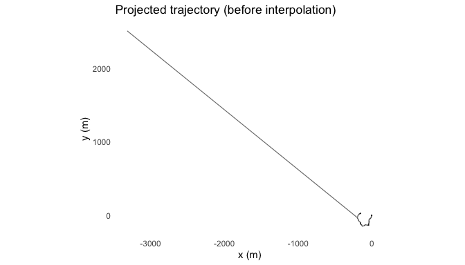

```r
ggplot(tr, aes(x, y)) +
  geom_path(alpha = 0.6, linewidth = 0.4) +
  coord_fixed() +
  labs(title = "Projected trajectory (before interpolation)",
       x = "x (m)", y = "y (m)") +
  theme_minimal() +
  theme(panel.grid = element_blank())
```

## 5. Interpolate — regularise the frame rate

GPS signals drop out. `interpolate()` builds a regular 10 Hz time grid and fills short gaps linearly. Gaps longer than `max_gap_frames` rows are left as `NA` rather than invented — preserving the 14-second gap flagged earlier.

```r
tr <- interpolate(tr, hz = 10, method = "linear", max_gap_frames = 20)
```

## 6. Filtrate — smooth the coordinates

### Find the cutoff

`filtrate_cutoff()` sweeps a range of Butterworth cutoffs and plots the residual curve. The elbow marks where smoothing starts removing real signal rather than noise.

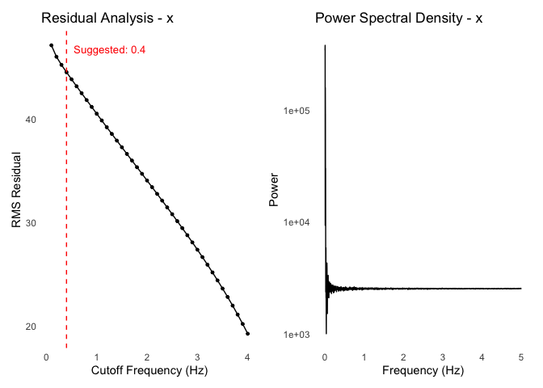

```r
filtrate_cutoff(
  tr,
  method       = "butterworth",
  target       = "coordinates",
  axis         = "x",
  plot_type    = "both",
  cutoff_range = c(0.1, 4),
  n_steps      = 40
)
```

A cutoff of **~1–2 Hz** is typical for GPS position data at 10 Hz. The dashed red line is the suggested value — adjust based on the PSD panel.

### Apply the filter

`filtrate()` stores the smoothed signal in `f_x`, `f_y` columns and leaves the originals untouched. `derivate()` will use the filtered columns by default.

```r
tr <- filtrate(tr, method = "butterworth", target = "coordinates", cutoff = 1.5)
```

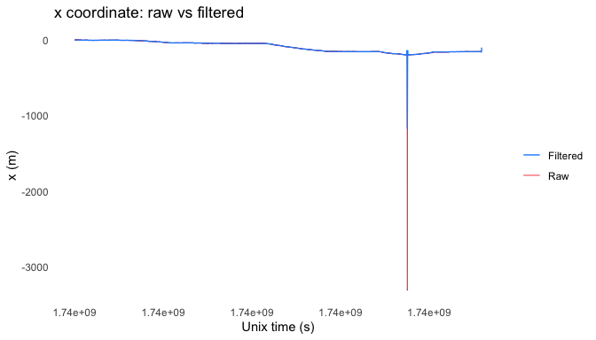

```r
drop_na(tr, f_x) |>
  ggplot(aes(x = unix_time)) +
  geom_line(aes(y = x,   colour = "Raw"),      linewidth = 0.3) +
  geom_line(aes(y = f_x, colour = "Filtered"), linewidth = 0.5) +
  scale_colour_manual(values = c(Raw = "firebrick2", Filtered = "dodgerblue")) +
  labs(title = "x coordinate: raw vs filtered",
       x = "Unix time (s)", y = "x (m)", colour = NULL) +
  theme_minimal() +
  theme(panel.grid = element_blank())
```

## 7. Derivate — velocity, acceleration, angular velocity

`derivate()` computes derivatives using central differences. It uses the filtered `f_x`, `f_y` columns by default.

```r
tr <- derivate(
  tr,
  use_filtered = TRUE,
  derivatives  = c("velocity", "acceleration", "angular_velocity")
)
```

Angular velocity captures whether the player is running straight or turning — a continuous signal more nuanced than a discrete “change of direction” event:

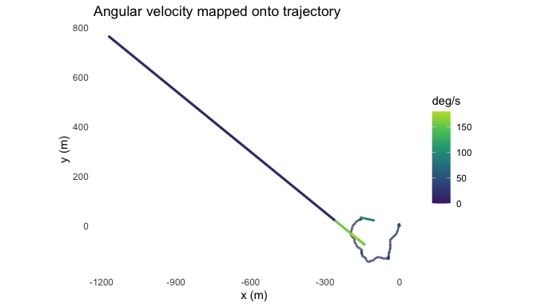

```r
drop_na(tr, angular_velocity) |>
  ggplot(aes(f_x, f_y, colour = angular_velocity)) +
  geom_path(linewidth = 1) +
  coord_fixed() +
  scale_colour_viridis_c(option = "viridis", begin = 0.1, end = 0.9) +
  labs(title = "Angular velocity mapped onto trajectory",
       x = "x (m)", y = "y (m)", colour = "deg/s") +
  theme_minimal() +
  theme(panel.grid = element_blank())
```

## 8. Designate — identify activity bouts

`designate()` uses PELT changepoint detection on the velocity signal to split the session into contiguous active bouts and relief periods — no manual timestamps required.

```r
tr <- designate(tr, method = "corbett", v_threshold = 0.3)
```

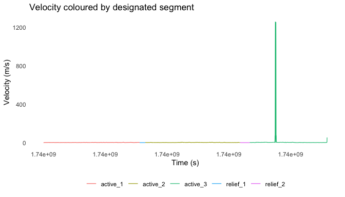

```r
ggplot(tr, aes(unix_time, velocity, colour = designation)) +
  geom_line(linewidth = 0.4) +
  labs(title = "Velocity coloured by designated segment",
       x = "Time (s)", y = "Velocity (m/s)", colour = NULL) +
  theme_minimal() +
  theme(panel.grid = element_blank(),
        legend.position = "bottom")
```

## 9. Elaborate — add custom metrics

`elaborate()` is a `motion_trace`-safe `dplyr::mutate()` wrapper. It preserves the `metadata` and `quality` attributes that a bare `mutate()` would silently drop. Use it to add computed columns or fix derived values before profiling:

```r
tr <- elaborate(
  tr,
  curved_load = velocity * abs(angular_velocity),  # direction-weighted load
  velocity    = pmin(velocity, 8)                  # cap GPS teleport spike
)
```

## 10. Allocate — assign intensity bands

`allocate()` cuts any derivative into labelled bands. Call it multiple times with different `allocation_name` values to layer profiling schemes on the same trace without conflict:

```r
tr <- allocate(
  tr,
  allocation = list(
    velocity     = c(0, 2, 4, 6, 8),
    acceleration = c(0, 1, 2, 3)
  ),
  allocation_name = "gps_bands"
)
```

## 11. Quantitate — summarise

`quantitate()` aggregates by designation segment and intensity band. The full quality log is preserved as an attribute on the result.

**By segment and velocity band:**

```r
by_segment <- quantitate(
  tr,
  allocation  = "gps_bands",
  derivative  = "velocity",
  scope       = "designation",
  active_only = TRUE,
  time_s      = n() / 10,
  peak_vel    = max(velocity, na.rm = TRUE),
  mean_hr     = mean(HeartRate, na.rm = TRUE)
)

by_segment
```

```
#> # A tibble: 10 × 5
#>    designation gps_bands_velocity_band time_s peak_vel mean_hr
#>    <chr>       <ord>                    <dbl>    <dbl>   <dbl>
#>  1 active_1    band_1                   129       2.00    137.
#>  2 active_1    band_2                    26.2     3.94    151.
#>  3 active_1    band_3                     0.4     4.37    152.
#>  4 active_2    band_1                   120.      2.00    138.
#>  5 active_2    band_2                    32       3.95    162.
#>  6 active_2    band_3                     0.9     4.21    167.
#>  7 active_3    band_1                    72.4     2.00    129.
#>  8 active_3    band_2                    46.4     3.95    173.
#>  9 active_3    band_3                     3.6     5.86    173.
#> 10 active_3    band_4                     2.8     8       171.
```

**Session totals:**

```r
session_totals <- quantitate(
  tr,
  allocation  = "gps_bands",
  derivative  = "velocity",
  scope       = "session",
  active_only = TRUE,
  time_s      = n() / 10,
  peak_vel    = max(velocity, na.rm = TRUE),
  mean_hr     = mean(HeartRate, na.rm = TRUE)
)

session_totals
```

[output not shown]

## Appendix: quality log

Every step appends to the quality log. Inspect it at any point — here at the end you can see the full provenance of everything done to the trace:

```r
quality_report(tr)
```

```
#> ═══════════════════════════════════════════════════════════
#>             MOTION TRACE QUALITY REPORT
#> ═══════════════════════════════════════════════════════════
#>
#> Session: marquee_gps_file.csv
#> Source:  template_csv
#>
#> Processing: initiate → coordinate → interpolate → filtrate → derivate → designate → elaborate → allocate
#>
#> ───────────────────────────────────────────────────────────
#>  INITIATE
#> ───────────────────────────────────────────────────────────
#>   Timestamp:     2026-05-25 16:40:22
#>   Rows:          4,200
#>   Completeness:  99.4% (4,175 valid coordinates)
#>   Sample Rate:   10.00 Hz (0.100 s median interval)
#>   Duration:      7.6 minutes
#>   Gaps:          3 (0.1% of intervals, largest: 14.1s)
#>   Duplicates:    3 timestamps
#>
#>   Status: ✗ ISSUES DETECTED
#>
#>   Issues:
#>     ✗ Large temporal gap detected: 14.1 seconds
#>
#>   Warnings:
#>     ⚠ Duplicate timestamps: 3 points
#>
#> ───────────────────────────────────────────────────────────
#>  COORDINATE
#> ───────────────────────────────────────────────────────────
#>   Timestamp:     2026-05-25 16:40:22
#>   Rows:          4,200
#>
#>   Conversion Path
#>     From:        latlong
#>     To:          xyz
#>     Method:      Lat/Lng → projected XYZ (via sf)
#>
#>   Coordinate Reference System
```

[output cut: 156 more lines]

```
#>   Call 1  —  2026-05-25 16:40:23
#>     Grouped by:  (none)
#>     Added:       curved_load
#>     Modified:    velocity
#>
#> ───────────────────────────────────────────────────────────
#>  ALLOCATE
#> ───────────────────────────────────────────────────────────
#>   Allocations applied: 1
#>
#>   [gps_bands]  defined manually
#>     velocity             4 bands   [0, 2), [2, 4), [4, 6), [6, 8)
#>     acceleration         3 bands   [0, 1), [1, 2), [2, 3)
#>
#> ═══════════════════════════════════════════════════════════
```

## Saving results

`write_csv` drops R attributes. Use `saveRDS` to keep the full object:

```r
saveRDS(tr, "session_processed.rds")

readr::write_csv(by_segment, "by_segment.csv")

saveRDS(attr(tr, "quality"), "quality_log.rds")
```

## Pipeline at a glance

```r
tr <- initiate(session = path,
               template = load_csv_template("my_device.xml"),
               verbose  = FALSE) |>
  coordinate(norm = TRUE) |>
  interpolate(hz = 10, max_gap_frames = 20) |>
  filtrate(method = "butterworth", target = "coordinates", cutoff = 1.5) |>
  derivate(use_filtered = TRUE,
           derivatives  = c("velocity", "acceleration", "angular_velocity")) |>
  designate(method = "corbett", v_threshold = 0.3) |>
  elaborate(curved_load = velocity * abs(angular_velocity),
            velocity    = pmin(velocity, 8)) |>
  allocate(allocation      = list(velocity = c(0, 2, 4, 6, 8)),
           allocation_name = "gps_bands")
```